# Coffee_shop

## Logo

[figure not shown]

## Location

This is for this restaurant [space](https://www.loopnet.com/Listing/45-1151-Kamehameha-Hwy-Kaneohe-HI/39960141/) in Kaneohe, 21.418373774996557, -157.80145495447087

## Competition

Primary competition for this business is unfilled as what would be traditionally considered coffee shops in the area (roughly 5 miles) is solely Starbucks. Starbucks still proves to be tough competition for most coffee shops however if the brand fills a quality cafe style niche there will still be a sizeable market for most coffee shops. In the niche we are looking at the primary competitor is Tradition Coffee Roasters in Kapaa Quarry roughly 5 miles away and a 10 to 15 minute drive. Our major advantage over Tradition Coffee would be primarily an earlier opening time giving many the opportunity to get coffee BEFORE rush hour.

## Resident Customer Demographics

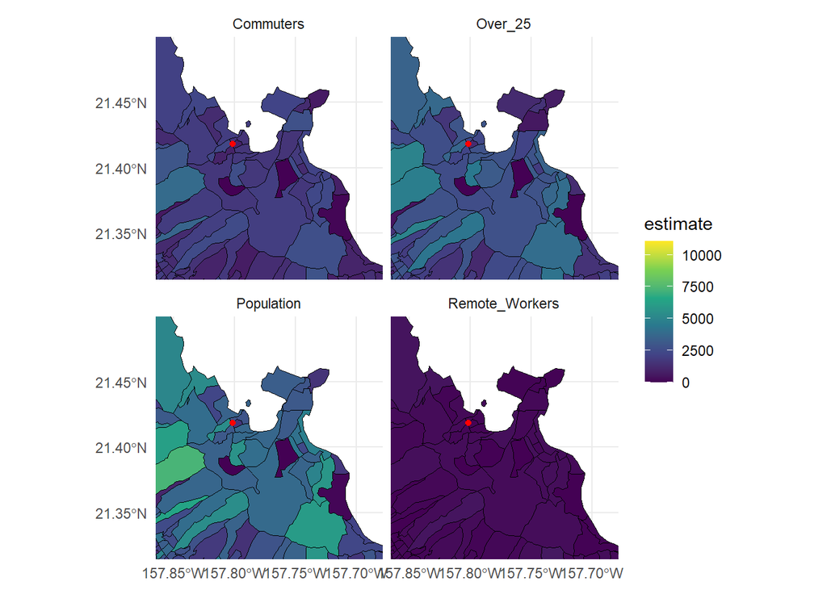

Looking at the demographics of the area we can see that the Kaneohe and Ahuimanu area houses some 30-40 thousand people and a good proportion of them are over 25 year old commuters. Thanks to Oahu’s large tourism industry our customer base wouldn’t have to be completely local but it’s good to have a reliable source of revenue nonetheless.

## Step 4.2 - Working Customer Demographics

```
# A tibble: 10 × 5
   tract       workers_in workers_out net_flow self_containment
   <chr>            <dbl>       <dbl>    <dbl>            <dbl>
 1 15009031601       1343         536      -47            0.614
 2 15001021708       4610         247     4196            0.403
 3 15009031700       1068        1067     -572            0.349
 4 15003004000      28885        1191    27200            0.293
 5 15007040500       7463        3349     2819            0.279
 6 15003981400      13506         119    13342            0.274
 7 15003981300       7324         149     7120            0.270
 8 15009030100        476         536     -257            0.269
 9 15007040104        788         212      501            0.261
10 15009031503       6220        1275     4518            0.251
```

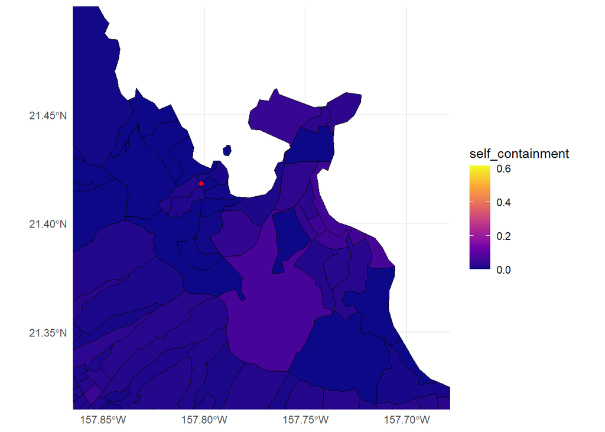

In terms of workers in the area we can see that most of them do not work in the same region in which they live however this becomes tricky in kaneohe with its small and numerous tracts.

## What’s Nearby?

[interactive chart not shown]

Nearby we have Windward Mall, Windward Community College and He’eia Boat Harbor. Kaneohe is also a common place to travel through in getting to North Shore and Kualoa ranch meaning that there is some tourism presence in the area. In the same building Adela’s Country Eatery a popular place to get lunch which means there will be a consistent flow of foot traffic during their operating hours.

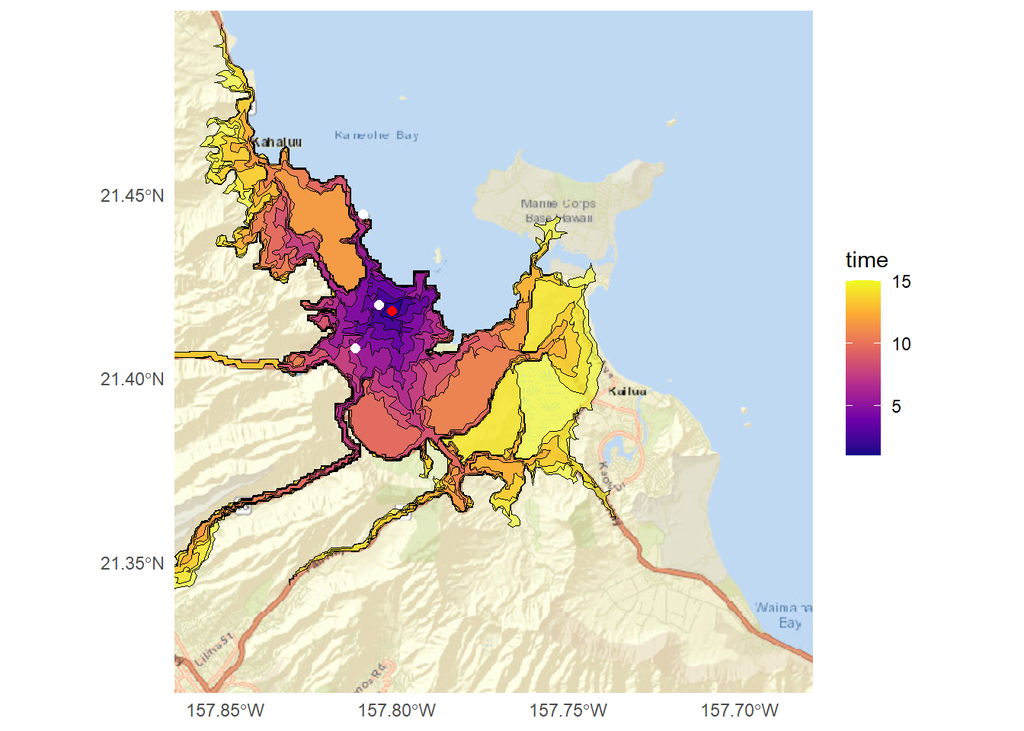

## Do we Need a Generator?

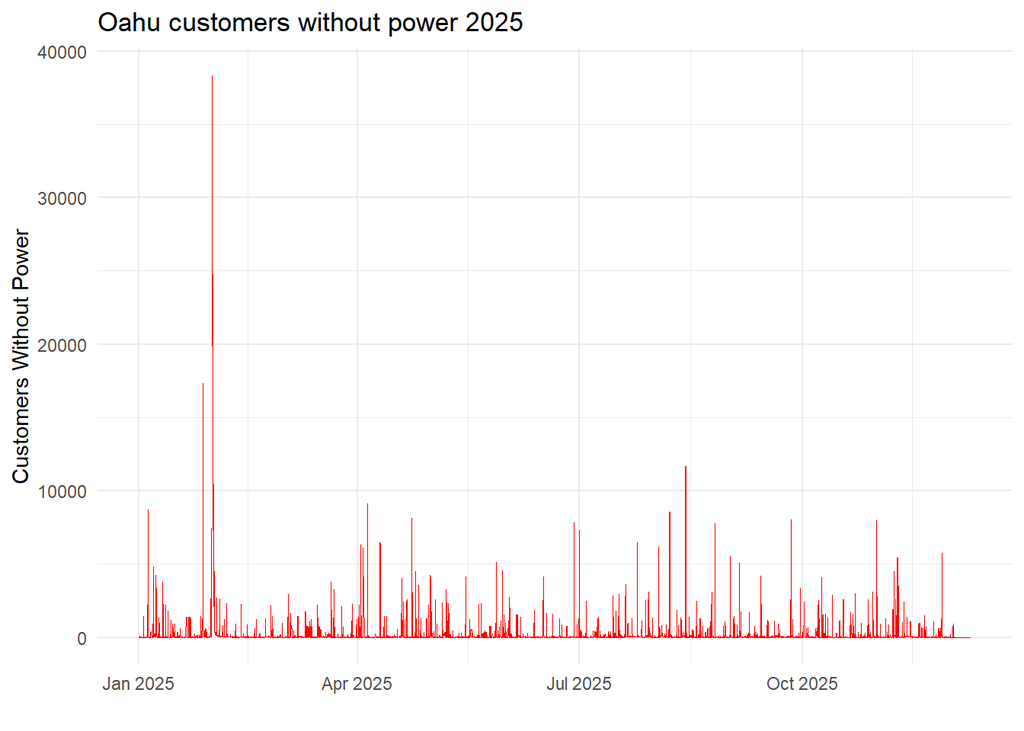

Since eagle I doesn’t filter down to the tract level we can’t determine from this data whether our business in particular would be effected by these outages. Looking at the data there were a couple significant spikes in January that could easily encompass the business but any more than three or four outages in 2025 would be wild guessing. A generator may still be wise though.

## Solar ?

[interactive chart not shown]

SAM3 Identified one set of solar panels on the roof of the building, however there doesn’t appear to be enough to power 5 businesses simultaneously.